# Cox vs GLM Approximation: A Four-Way Comparison

Validating the GLM Power Approximation via the Poisson-Cox Equivalence

Author

Larry F. Leon

Published

April 3, 2026

# 1 Introduction

Leon et al. (2024, Section 2.1) developed an asymptotic approximation for the probability that ForestSearch identifies a subgroup $H$ with true log-hazard ratio $\beta$:

$$p(c_1, c_2; d, \theta^\dagger(H)) =
P(W_1 + W_2 \ge 2\log c_1, \;\min(W_1, W_2) \ge \log c_2)
\tag{3}$$

with $W_1, W_2 \stackrel{\text{iid}}{\sim} N(\beta, 8/d)$, where $d$ is the expected number of events in $H$.

This document validates the extension of (3) to GLM outcomes by exploiting the **Poisson-Cox equivalence**: on the same survival data, Poisson regression with log(time) offset estimates the same quantity as the Cox model, so both approximations should agree.

We compare four calculations:

| Label | Method | Source |
| --- | --- | --- |
| **(A)** | ForestSearch Poisson+offset simulation | GLM pipeline |
| **(B)** | GLM approximation: $d_{\text{eff}} = D$ | GLM theory |
| **(C)** | ForestSearch Cox PH simulation | Established pipeline |
| **(D)** | Cox approximation: `compute_detection_probability()` | Package (Section 2.1) |

Since $d_{\text{eff}}^{\text{Poisson}} = D = d^{\text{Cox}}$ (both equal the number of events), **(B)** and **(D)** should be identical, and **(A)** and **(C)** should agree closely.

# 2 Theoretical Framework

## 2.1 The Cox Score Statistic Argument (Section 2.1)

For the Cox model $\lambda(t; V) = \lambda_0(t)\exp(\beta V)$, the score statistic $L_d(\beta)$ based on $d$ events satisfies $\hat\beta_s \approx (4/d) L_d(0) \sim N(\beta, 4/d)$ (Jennison and Turnbull, 1984).

For a random 50/50 split of the subgroup, the split-half score statistics $L_{d_1}$ and $L_{d_2}$ with $d_1 \approx d_2 \approx d/2$ give:

$$\hat\beta^1_s, \hat\beta^2_s \stackrel{\text{iid}}{\sim}
N(\beta, \; 8/d)$$

since $\text{Var}(\hat\beta_{\text{half}}) = 4/(d/2) = 8/d$. By construction $\hat\beta_s \approx (\hat\beta^1_s + \hat\beta^2_s)/2$, so the screening condition $\hat\beta_s \ge \log(c_1)$ is equivalent to $\hat\beta^1_s + \hat\beta^2_s \ge 2\log(c_1)$, yielding (3).

## 2.2 The GLM Analog

For a canonical GLM with treatment as the sole covariate, the MLE $\hat\beta$ is asymptotically normal by standard likelihood theory (McCullagh and Nelder, 1989, Ch. 2):

$$\hat\beta \stackrel{d}{\to}
N(\beta, \; I^{-1}(\beta))$$

where $I(\beta)$ is the Fisher information. For balanced arms ($n_1 = n_0 = n_H/2$), the Fisher information takes the form $I(\beta) = (n_H/4) \cdot \kappa$, giving:

$$\text{Var}(\hat\beta_{\text{full}}) = \frac{4}{n_H \cdot \kappa}
= \frac{4}{d_{\text{eff}}}$$

The family-specific $\kappa$ and corresponding $d_{\text{eff}}$:

### 2.2.1 Poisson (log link, with offset)

For the Poisson model $\log E[Y_i] = \beta_0 + \beta V_i + \log(t_i)$, the Fisher information for $\beta$ is:

$$I(\beta) = \sum_{j=0}^{1} d_j, \quad
d_j = \sum_{i: V_i = j} E[Y_i] = \sum_{i: V_i = j} \mu_i$$

where $d_j$ is the expected number of events in arm $j$. For balanced arms with total events $D = d_0 + d_1$:

$$\text{Var}(\hat\beta_{\text{full}}) = \frac{1}{d_0} + \frac{1}{d_1}
\approx \frac{4}{D}$$

Therefore $d_{\text{eff}}^{\text{Poisson}} = D$ (total events).

### 2.2.2 Cox PH

For the Cox model, the partial likelihood score gives $\text{Var}(\hat\beta) \approx 4/d$ where $d$ is the number of events. Therefore $d^{\text{Cox}} = d$ (events).

### 2.2.3 The Equivalence

Under proportional hazards with a piecewise-constant baseline hazard, the Poisson regression with log(time) offset and the Cox model estimate the same log-hazard ratio (Laird and Olivier, 1981; Whitehead, 1980). The key identity is:

$$d_{\text{eff}}^{\text{Poisson}} = D = d^{\text{Cox}}$$

Both equal the number of observed events in the subgroup. Therefore the split-half variance $8/d_{\text{eff}}$ is identical, and the approximation (3) gives the same result for both models.

### 2.2.4 Other GLM Families

| Family | Link | $\kappa$ | $d_{\text{eff}}$ |
| --- | --- | --- | --- |
| Cox PH | log-HR | $(1-p_c)$ | $d$ (events) |
| Poisson + offset | log-IRR | $\bar\mu$ | $D$ (events) |
| Binomial | logit | $\bar p(1-\bar p)$ | $n_H \bar p(1-\bar p)$ |
| Gaussian | identity | $1/\sigma^2$ | $n_H / \sigma^2$ |

For binary outcomes (no offset), $d_{\text{eff}} = n_H \bar p(1-\bar p)$, which is generally smaller than $D$ for survival data, explaining the different operating characteristics observed in binary threshold calibration.

# 3 Setup

```r
library(forestsearch)
library(weightedsurv)
library(data.table)
library(survival)
library(ggplot2)
library(patchwork)
library(gt)
library(foreach)
library(doFuture)
library(future)

# L_eff save/load helpers
#source(here::here("R", "leff_calibration_io.R"))
plan(multisession, workers = n_workers)
cat("Using", n_workers, "parallel workers\n")
```

```
#> Using 121 parallel workers
```

```r
cat("H1 sims:", nsims_alt, "| H0 sims:", nsims_null, "\n")
```

```
#> H1 sims: 1000 | H0 sims: 10000
```

```r
timings <- list()
t_vignette_start <- proc.time()
```

# 4 Data Generating Mechanism

We use the GBSG-based DGM from Leon et al. (2024). The harm subgroup H = {ER-low AND premenopausal} has $\theta^\dagger(H) > 1$, while the complement benefits ($\theta^\dagger(H^c) < 1$).

## 4.1 Alternative and Null DGMs

```r
t0 <- proc.time()[3]

# Alternative: calibrate for HR(H) = hr_h1 (from setup)
k_inter_cox <- calibrate_k_inter(
  target_hr_harm = hr_h1,
  model = "alt",
  k_treat = 1.0,
  cens_type = "weibull",
  use_ahr = FALSE,
  verbose = TRUE
)
```

```
#> Calibrating k_inter to achieve HR(H) = 2.0000
```

```
#> Search range: [-100.0, 100.0]
```

```
#> HR(H) at k_inter = -100.0: 0.0000
```

```
#> HR(H) at k_inter = 100.0: 2013671808.8162
```

```
#>
#> === Calibration Result ===
```

```
#> Found k_inter = 1.494664
```

```
#> Achieved HR(H) = 2.0000 (target: 2.0000)
```

```
#> Error: 0.000001
```

```
#> Iterations: 53
```

```r
dgm_alt <- setup_gbsg_dgm(
  model = "alt", k_treat = 1.0, k_inter = k_inter_cox, verbose = TRUE
)
```

```
#> === GBSG DGM Creation (Aligned) ===
```

```
#> Model type: alt
```

```
#> Effect modifiers: k_treat = 1.000, k_inter = 1.495, k_z3 = 1.000
```

```
#> Sample size: 686
```

```
#> Events: 299 (43.6%)
```

```
#> Harm subgroup size: 84 (12.2%)
```

```
#> ER threshold (z1_quantile = 0.25): 8.0
```

```
#>
#> --- Original AFT Coefficients ---
```

```
#> sigma (scale): 0.7132
```

```
#> mu (intercept): 4.4492
```

```
#> gamma coefficients:
```

```
#>   treat: 0.3826
```

```
#>   z1: 0.0220
```

```
#>   z2: -0.0481
```

```
#>   z3: 0.0275
```

```
#>   z4: 0.2457
```

```
#>   z5: -0.3272
```

```
#>   zh: -0.6737
```

```
#>
#> --- Modified AFT Coefficients ---
```

```
#> gamma['treat']: 0.3826 -> 0.3826 (k_treat = 1.000)
```

```
#> gamma['z3']: 0.0275 -> 0.0275 (k_z3 = 1.000)
```

```
#> gamma['zh']: -0.6737 -> -1.0070 (k_inter = 1.495)
```

```
#>
#> --- Theoretical HRs (from coefficients) ---
```

```
#> HR(H) = exp(b0['treat'] + b0['zh']) = exp(-0.5365 + 1.4120) = 2.4001
```

```
#> HR(Hc) = exp(b0['treat']) = exp(-0.5365) = 0.5848
```

```
#>
#> --- Hazard Ratios (Stacked Potential Outcomes) ---
```

```
#> HR (overall/causal): 0.7216
```

```
#> HR (harm subgroup, H): 2.0000
```

```
#> HR (complement, Hc): 0.6612
```

```
#>
#> --- Average Hazard Ratios (from loghr_po) ---
```

```
#> AHR (overall): 0.6994
```

```
#> AHR (harm subgroup, H): 2.4001
```

```
#> AHR (complement, Hc): 0.5848
```

```
#>
#> HR(H) / HR(Hc) ratio: 3.0249
```

```
#> AHR(H) / AHR(Hc) ratio: 4.1043
```

```r
dgm_alt <- compute_dgm_cde(dgm_alt)

cat(sprintf("\nCalibrated Alternative DGM (target HR(H) = %.1f):\n", hr_h1))
```

```
#>
#> Calibrated Alternative DGM (target HR(H) = 2.0):
```

```r
cat("  HR(H):", round(dgm_alt$hr_H_true, 3), "\n")
```

```
#>   HR(H): 2
```

```r
cat("  HR(Hc):", round(dgm_alt$hr_Hc_true, 3), "\n")
```

```
#>   HR(Hc): 0.661
```

```r
cat("  HR(ITT):", round(dgm_alt$hr_causal, 3), "\n")
```

```
#>   HR(ITT): 0.722
```

```r
# Null: uniform treatment effect
dgm_null <- setup_gbsg_dgm(model = "null", k_treat = 1.0, verbose = TRUE)
```

```
#> === GBSG DGM Creation (Aligned) ===
```

```
#> Model type: null
```

```
#> Effect modifiers: k_treat = 1.000, k_inter = 1.000, k_z3 = 1.000
```

```
#> Sample size: 686
```

```
#> Events: 299 (43.6%)
```

```
#> Harm subgroup size: 0 (0.0%)
```

```
#> ER threshold (z1_quantile = 0.25): 8.0
```

```
#>
#> --- Original AFT Coefficients ---
```

```
#> sigma (scale): 0.7151
```

```
#> mu (intercept): 4.4590
```

```
#> gamma coefficients:
```

```
#>   treat: 0.3034
```

```
#>   z1: -0.0411
```

```
#>   z2: -0.0393
```

```
#>   z3: -0.0118
```

```
#>   z4: 0.2464
```

```
#>   z5: -0.3234
```

```
#>
#> --- Modified AFT Coefficients ---
```

```
#> gamma['treat']: 0.3034 -> 0.3034 (k_treat = 1.000)
```

```
#> gamma['z3']: -0.0118 -> -0.0118 (k_z3 = 1.000)
```

```
#>
#> --- Hazard Ratios (Stacked Potential Outcomes) ---
```

```
#> HR (overall/causal): 0.7223
```

```
#> HR (harm subgroup, H): NA
```

```
#> HR (complement, Hc): 0.7223
```

```
#>
#> --- Average Hazard Ratios (from loghr_po) ---
```

```
#> AHR (overall): 0.6543
```

```
#> AHR (harm subgroup, H): NA
```

```
#> AHR (complement, Hc): 0.6543
```

```r
cat("\nNull DGM:\n")
```

```
#>
#> Null DGM:
```

```r
cat("  HR(ITT):", round(dgm_null$hr_causal, 3), "\n")
```

```
#>   HR(ITT): 0.722
```

```r
timings$dgm <- proc.time()[3] - t0
```

# 5 Part I: Approximation Calculations

## 5.1 (D) Cox Approximation (Section 2.1, from package)

```r
# n_H_values defined in setup chunk
cat("=== (D) Cox Approximation ===\n")
```

```
#> === (D) Cox Approximation ===
```

```r
cat("Using compute_detection_probability() from forestsearch\n\n")
```

```
#> Using compute_detection_probability() from forestsearch
```

```r
approx_cox <- data.frame(
  n_H = n_H_values,
  d = round(d_eff_survival(n_H_values, prop_cens)),
  stringsAsFactors = FALSE
)

# Type-I error: theta = 1.0
approx_cox$P_theta_1.0 <- sapply(approx_cox$n_H, function(n) {
  compute_detection_probability(
    theta = 1.0, n_sg = n, prop_cens = prop_cens,
    hr_threshold = 1.25, hr_consistency = 1.0
  )
})

# Power: theta = hr_h1
approx_cox[[sprintf("P_theta_%.1f", hr_h1)]] <-
  sapply(approx_cox$n_H, function(n) {
    compute_detection_probability(
      theta = hr_h1, n_sg = n, prop_cens = prop_cens,
      hr_threshold = 1.25, hr_consistency = 1.0
    )
  })

# Beneficial null: theta = 0.75
approx_cox$P_theta_0.75 <- sapply(approx_cox$n_H, function(n) {
  compute_detection_probability(
    theta = 0.75, n_sg = n, prop_cens = prop_cens,
    hr_threshold = 1.25, hr_consistency = 1.0
  )
})
```

## 5.2 (B) GLM Approximation (d_eff-based)

```r
# Use compute_detection_probability_glm() and d_eff_*() helpers
# from forestsearch (R/truefind_asymptotic_glm.R).
# Shorthand wrapper for concise calls:
p_detect_glm <- function(theta, d_eff, c1, c2) {
  compute_detection_probability_glm(
    theta = theta, d_eff = d_eff, c1 = c1, c2 = c2,
    effect_scale = "ratio", method = "monte_carlo"
  )
}

cat("=== (B) GLM Approximation ===\n")
```

```
#> === (B) GLM Approximation ===
```

```r
cat("Using d_eff = D (events) for Poisson+offset\n")
```

```
#> Using d_eff = D (events) for Poisson+offset
```

```r
cat("Via compute_detection_probability_glm() from forestsearch\n\n")
```

```
#> Via compute_detection_probability_glm() from forestsearch
```

```r
approx_glm <- data.frame(
  n_H = n_H_values,
  d_eff = round(d_eff_survival(n_H_values, prop_cens)),
  stringsAsFactors = FALSE
)

approx_glm$P_theta_1.0 <- sapply(approx_glm$d_eff, function(d) {
  p_detect_glm(1.0, d, 1.25, 1.0)
})

approx_glm[[sprintf("P_theta_%.1f", hr_h1)]] <-
  sapply(approx_glm$d_eff, function(d) {
    p_detect_glm(hr_h1, d, 1.25, 1.0)
  })

approx_glm$P_theta_0.75 <- sapply(approx_glm$d_eff, function(d) {
  p_detect_glm(0.75, d, 1.25, 1.0)
})
```

## 5.3 (B) vs (D): Approximation Agreement

```r
approx_comp <- data.frame(
  n_H = approx_cox$n_H,
  d = approx_cox$d,
  `Cox P(1.0)` = round(approx_cox$P_theta_1.0, 4),
  `GLM P(1.0)` = round(approx_glm$P_theta_1.0, 4),
  `Cox P(hr_h1)` = round(approx_cox[[sprintf("P_theta_%.1f", hr_h1)]], 4),
  `GLM P(hr_h1)` = round(approx_glm[[sprintf("P_theta_%.1f", hr_h1)]], 4),
  `Cox P(0.75)` = round(approx_cox$P_theta_0.75, 4),
  `GLM P(0.75)` = round(approx_glm$P_theta_0.75, 4),
  check.names = FALSE
)
names(approx_comp)[5] <- sprintf("Cox P(%.1f)", hr_h1)
names(approx_comp)[6] <- sprintf("GLM P(%.1f)", hr_h1)

gt(approx_comp) |>
  tab_header(
    title = "(B) vs (D): GLM and Cox Approximations",
    subtitle = "d_eff(Poisson) = d(Cox) = events. Values should match."
  ) |>
  tab_spanner(label = "Type-I Error (HR=1)", columns = 3:4) |>
  tab_spanner(label = sprintf("Power (HR=%.1f)", hr_h1), columns = 5:6) |>
  tab_spanner(label = "Beneficial (HR=0.75)", columns = 7:8) |>
  tab_source_note("c1=1.25, c2=1.0, censoring=46%")
```

Cox approximation (D) vs GLM approximation (B). Since d_eff = d, these should be identical.

(B) vs (D): GLM and Cox Approximations

d_eff(Poisson) = d(Cox) = events. Values should match.

| n_H | d | Type-I Error (HR=1) Cox P(1.0) | Type-I Error (HR=1) GLM P(1.0) | Power (HR=2.0) Cox P(2.0) | Power (HR=2.0) GLM P(2.0) | Beneficial (HR=0.75) Cox P(0.75) | Beneficial (HR=0.75) GLM P(0.75) |
| --- | --- | --- | --- | --- | --- | --- | --- |
| 60 | 32 | 0.1937 | 0.1944 | 0.8247 | 0.8222 | 0.0502 | 0.0513 |
| 80 | 43 | 0.1780 | 0.1786 | 0.8787 | 0.8777 | 0.0335 | 0.0341 |
| 91 | 49 | 0.1700 | 0.1704 | 0.9005 | 0.8993 | 0.0270 | 0.0274 |
| 100 | 54 | 0.1636 | 0.1640 | 0.9153 | 0.9144 | 0.0226 | 0.0231 |
| 120 | 65 | 0.1505 | 0.1506 | 0.9404 | 0.9401 | 0.0154 | 0.0155 |

c1=1.25, c2=1.0, censoring=46%

## 5.4 Power Curves: (B) and (D)

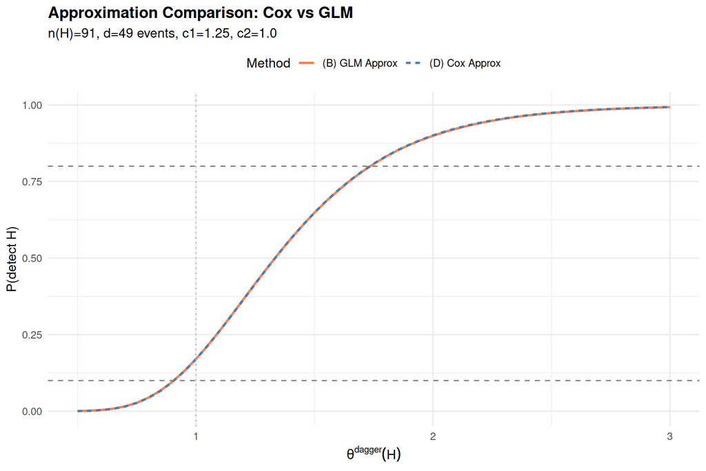

Power curves from both approximations. The two curves should be indistinguishable (validating d_eff = d).

```r
# n_sg_ref and d defined from setup-chunk scalars
d_ref <- round(d_eff_survival(n_sg_ref, prop_cens))

hr_seq <- seq(0.5, 3.0, by = 0.05)

cox_curve <- sapply(hr_seq, function(hr) {
  compute_detection_probability(hr, n_sg_ref, prop_cens, 1.25, 1.0)
})
glm_curve <- sapply(hr_seq, function(hr) {
  p_detect_glm(hr, d_ref, 1.25, 1.0)
})

curve_df <- data.frame(
  OR = rep(hr_seq, 2),
  P_detect = c(cox_curve, glm_curve),
  Method = rep(c("(D) Cox Approx", "(B) GLM Approx"), each = length(hr_seq))
)

ggplot(curve_df, aes(x = OR, y = P_detect, colour = Method, linetype = Method)) +
  geom_line(linewidth = 1.0) +
  geom_hline(yintercept = c(0.10, 0.80), linetype = "dashed", colour = "grey50") +
  geom_vline(xintercept = 1.0, linetype = "dotted", colour = "grey70") +
  scale_colour_manual(values = c("(D) Cox Approx" = "steelblue",
                                  "(B) GLM Approx" = "coral")) +
  labs(x = expression(theta^dagger*(H)),
       y = "P(detect H)",
       title = "Approximation Comparison: Cox vs GLM",
       subtitle = sprintf("n(H)=%d, d=%d events, c1=1.25, c2=1.0",
                          n_sg_ref, d_ref)) +
  theme_minimal(base_size = 12) +
  theme(legend.position = "top", plot.title = element_text(face = "bold"))
```

# 6 Part II: Simulation

## 6.1 QC: Single-Trial Equivalence

```r
sim_data <- simulate_from_dgm(
  dgm = dgm_alt, n = n_sample, rand_ratio = 1,
  seed = 1, analysis_time = analysis_time,
  cens_adjust = cens_adjust
)
sim_data$id <- seq_len(nrow(sim_data))

cat("Simulated trial: N =", nrow(sim_data),
    "| Events =", sum(sim_data$event_sim),
    "(", round(100 * mean(sim_data$event_sim), 1), "%)\n")
```

```
#> Simulated trial: N = 700 | Events = 351 ( 50.1 %)
```

```r
# Cox HR
fit_cox <- coxph(Surv(y_sim, event_sim) ~ treat_sim, data = sim_data)
cox_hr <- exp(coef(fit_cox))
cox_se <- sqrt(vcov(fit_cox)[1, 1])

# Poisson IRR
fit_pois <- glm(event_sim ~ treat_sim + offset(log(y_sim)),
                family = poisson, data = sim_data)
pois_irr <- exp(coef(fit_pois)["treat_sim"])
pois_se <- sqrt(vcov(fit_pois)["treat_sim", "treat_sim"])

cat(sprintf("\nITT Estimates:\n  Cox HR:      %.4f (SE: %.4f)\n  Poisson IRR: %.4f (SE: %.4f)\n  Ratio:       %.4f\n",
            cox_hr, cox_se, pois_irr, pois_se, cox_hr / pois_irr))
```

```
#>
#> ITT Estimates:
#>   Cox HR:      0.6899 (SE: 0.1076)
#>   Poisson IRR: 0.6951 (SE: 0.1076)
#>   Ratio:       0.9925
```

```r
d_obs <- sum(sim_data$event_sim)
cat(sprintf("\nVariance of log-effect:\n  Cox:     %.4f\n  Poisson: %.4f\n  4/d:     %.4f  (d = %d)\n",
            cox_se^2, pois_se^2, 4/d_obs, d_obs))
```

```
#>
#> Variance of log-effect:
#>   Cox:     0.0116
#>   Poisson: 0.0116
#>   4/d:     0.0114  (d = 351)
```

## 6.2 Simulation Parameters

```r
# Build compound parameter objects from setup-chunk scalars
fs_params_base <- list(
  hr.threshold = 1.25,
  hr.consistency = 1.0,
  pconsistency.threshold = pcons,
  fs.splits = fs_splits,
  n.min = n_min_val,
  d0.min = 12, d1.min = 12,
  maxk = maxk_val, by.risk = 12,
  vi.grf.min = -0.2,
  use_lasso = TRUE, use_grf = TRUE,
  use_twostage = TRUE, twostage_args = list(),
  parallel_args = list(plan="sequential", workers = 1, show_message = FALSE)
)

fs_params_cox <- modifyList(fs_params_base, list(
  outcome.name = "y_sim", event.name = "event_sim",
  treat.name = "treat_sim", id.name = "id"
))

fs_params_irr <- modifyList(fs_params_base, list(
  outcome.name = "y_sim", event.name = "event_sim",
  treat.name = "treat_sim", id.name = "id",
  outcome_type = "binary", effect_measure = "IRR",
  offset.name = "y_sim", dmin.grf = 0.0
))

sim_config <- list(
  n_sims_alt = nsims_alt,
  n_sims_null = nsims_null,
  n_sample = n_sample,
  analysis_time = analysis_time,
  seed_base = sim_seed,
  cens_adjust = cens_adjust
)

cat("Simulation config:\n")
```

```
#> Simulation config:
```

```r
cat("  H1 sims:", sim_config$n_sims_alt, "\n")
```

```
#>   H1 sims: 1000
```

```r
cat("  H0 sims:", sim_config$n_sims_null, "\n")
```

```
#>   H0 sims: 10000
```

```r
cat("  N:", sim_config$n_sample, "\n")
```

```
#>   N: 700
```

```r
cat("  analysis_time:", sim_config$analysis_time, "months\n")
```

```
#>   analysis_time: 84 months
```

```r
cat("  n.min:", fs_params_base$n.min, "(paper default)\n")
```

```
#>   n.min: 60 (paper default)
```

## 6.3 (C) Cox PH Simulations

```r
cat("Running Cox H1 simulations...\n")
```

```
#> Running Cox H1 simulations...
```

```r
t0 <- proc.time()[3]

results_alt_cox <- foreach(
  sim = seq_len(sim_config$n_sims_alt),
  .combine = rbind, .errorhandling = "remove",
  .options.future = list(
    packages = c("forestsearch", "survival", "data.table", "future"),
    seed = TRUE)
) %dofuture% {
  future::plan("sequential")
  run_simulation_analysis(
    sim_id = sim, dgm = dgm_alt,
    n_sample = sim_config$n_sample,
    analysis_time = sim_config$analysis_time,
    cens_adjust = sim_config$cens_adjust,
    confounders_base = confounders_base,
    cox_formula_adj = survival::Surv(y_sim, event_sim) ~ treat_sim + z1 + z2 + z3,
    n_add_noise = 0L,
    run_fs = TRUE, run_fs_grf = FALSE, run_grf = FALSE,
    fs_params = fs_params_cox, verbose = FALSE
  )
}
timings$alt_cox <- proc.time()[3] - t0
cat("Cox H1:", round(timings$alt_cox/60, 1), "min |",
    nrow(results_alt_cox), "rows\n")
```

```
#> Cox H1: 1.7 min | 1000 rows
```

```r
cat("Running Cox H0 simulations...\n")
```

```
#> Running Cox H0 simulations...
```

```r
t0 <- proc.time()[3]

results_null_cox <- foreach(
  sim = seq_len(sim_config$n_sims_null),
  .combine = rbind, .errorhandling = "remove",
  .options.future = list(
    packages = c("forestsearch", "survival", "data.table", "future"),
    seed = TRUE)
) %dofuture% {
  future::plan("sequential")
  run_simulation_analysis(
    sim_id = sim, dgm = dgm_null,
    n_sample = sim_config$n_sample,
    analysis_time = sim_config$analysis_time,
    cens_adjust = sim_config$cens_adjust,
    confounders_base = confounders_base,
    cox_formula_adj = survival::Surv(y_sim, event_sim) ~ treat_sim + z1 + z2 + z3,
    n_add_noise = 0L,
    run_fs = TRUE, run_fs_grf = FALSE, run_grf = FALSE,
    fs_params = fs_params_cox, verbose = FALSE
  )
}
timings$null_cox <- proc.time()[3] - t0
cat("Cox H0:", round(timings$null_cox/60, 1), "min\n")
```

```
#> Cox H0: 13.1 min
```

## 6.4 (A) Poisson IRR Simulations

```r
cat("Running Poisson IRR H1 simulations...\n")
```

```
#> Running Poisson IRR H1 simulations...
```

```r
t0 <- proc.time()[3]

results_alt_irr <- foreach(
  sim = seq_len(sim_config$n_sims_alt),
  .combine = rbind, .errorhandling = "remove",
  .options.future = list(
    packages = c("forestsearch", "survival", "data.table", "future"),
    seed = TRUE)
) %dofuture% {
  future::plan("sequential")
  run_simulation_analysis(
    sim_id = sim, dgm = dgm_alt,
    n_sample = sim_config$n_sample,
    analysis_time = sim_config$analysis_time,
    cens_adjust = sim_config$cens_adjust,
    confounders_base = confounders_base,
    cox_formula_adj = survival::Surv(y_sim, event_sim) ~ treat_sim + z1 + z2 + z3,
    n_add_noise = 0L,
    run_fs = TRUE, run_fs_grf = FALSE, run_grf = FALSE,
    fs_params = fs_params_irr, verbose = FALSE
  )
}
timings$alt_irr <- proc.time()[3] - t0
cat("IRR H1:", round(timings$alt_irr/60, 1), "min |",
    nrow(results_alt_irr), "rows\n")
```

```
#> IRR H1: 1.6 min | 1000 rows
```

```r
cat("Running Poisson IRR H0 simulations...\n")
```

```
#> Running Poisson IRR H0 simulations...
```

```r
t0 <- proc.time()[3]

results_null_irr <- foreach(
  sim = seq_len(sim_config$n_sims_null),
  .combine = rbind, .errorhandling = "remove",
  .options.future = list(
    packages = c("forestsearch", "survival", "data.table", "future"),
    seed = TRUE)
) %dofuture% {
  future::plan("sequential")
  run_simulation_analysis(
    sim_id = sim, dgm = dgm_null,
    n_sample = sim_config$n_sample,
    analysis_time = sim_config$analysis_time,
    cens_adjust = sim_config$cens_adjust,
    confounders_base = confounders_base,
    cox_formula_adj = survival::Surv(y_sim, event_sim) ~ treat_sim + z1 + z2 + z3,
    n_add_noise = 0L,
    run_fs = TRUE, run_fs_grf = FALSE, run_grf = FALSE,
    fs_params = fs_params_irr, verbose = FALSE
  )
}
timings$null_irr <- proc.time()[3] - t0
cat("IRR H0:", round(timings$null_irr/60, 1), "min\n")
```

```
#> IRR H0: 14.6 min
```

# 7 Part III: Four-Way Comparison

## 7.1 Simulation Operating Characteristics

```r
compare_metrics <- function(res_cox, res_irr) {
  cox <- res_cox[res_cox$analysis == "FS", ]
  irr <- res_irr[res_irr$analysis == "FS", ]
  cox_found <- cox[cox$any.H == 1, ]
  irr_found <- irr[irr$any.H == 1, ]

  data.frame(
    Metric = c("Detection Rate", "Sensitivity", "Specificity",
               "PPV", "NPV",
               "Mean Effect (H)", "Mean Effect (Hc)",
               "Mean Effect (ITT)", "Mean SG Size"),
    `(C) Cox PH` = c(
      round(mean(cox$any.H), 3),
      round(mean(cox$sens, na.rm = TRUE), 3),
      round(mean(cox$spec, na.rm = TRUE), 3),
      round(mean(cox$ppv, na.rm = TRUE), 3),
      round(mean(cox$npv, na.rm = TRUE), 3),
      round(mean(cox_found$hr.H.hat, na.rm = TRUE), 3),
      round(mean(cox_found$hr.Hc.hat, na.rm = TRUE), 3),
      round(mean(cox$hr.itt, na.rm = TRUE), 3),
      round(mean(cox_found$size.H, na.rm = TRUE), 0)),
    `(A) Poisson IRR` = c(
      round(mean(irr$any.H), 3),
      round(mean(irr$sens, na.rm = TRUE), 3),
      round(mean(irr$spec, na.rm = TRUE), 3),
      round(mean(irr$ppv, na.rm = TRUE), 3),
      round(mean(irr$npv, na.rm = TRUE), 3),
      round(mean(irr_found$hr.H.hat, na.rm = TRUE), 3),
      round(mean(irr_found$hr.Hc.hat, na.rm = TRUE), 3),
      round(mean(irr$hr.itt, na.rm = TRUE), 3),
      round(mean(irr_found$size.H, na.rm = TRUE), 0)),
    check.names = FALSE)
}
```

### 7.1.1 H1 (Alternative): Cox vs Poisson

```r
comp_h1 <- compare_metrics(results_alt_cox, results_alt_irr)

gt(comp_h1) |>
  tab_header(
    title = md("**H1: Cox PH (C) vs Poisson IRR (A)**"),
    subtitle = sprintf("N=%d, %d sims, true HR(H)=%.2f, HR(Hc)=%.2f",
      sim_config$n_sample, sim_config$n_sims_alt,
      dgm_alt$hr_H_true, dgm_alt$hr_Hc_true)
  ) |>
  tab_source_note("Detection/classification should be identical (same identification step)")
```

vs (C): Simulation comparison under H1

**H1: Cox PH (C) vs Poisson IRR (A)**

N=700, 1000 sims, true HR(H)=2.00, HR(Hc)=0.66

| Metric | (C) Cox PH | (A) Poisson IRR |
| --- | --- | --- |
| Detection Rate | 0.825 | 0.879 |
| Sensitivity | 0.866 | 0.863 |
| Specificity | 0.982 | 0.982 |
| PPV | 0.885 | 0.882 |
| NPV | 0.980 | 0.980 |
| Mean Effect (H) | 2.291 | 2.100 |
| Mean Effect (Hc) | 0.638 | 0.651 |
| Mean Effect (ITT) | 0.744 | 0.753 |
| Mean SG Size | 88.000 | 88.000 |

Detection/classification should be identical (same identification step)

### 7.1.2 H0 (Null): Cox vs Poisson

```r
comp_h0 <- compare_metrics(results_null_cox, results_null_irr)

gt(comp_h0) |>
  tab_header(
    title = md("**H0: Cox PH (C) vs Poisson IRR (A)**"),
    subtitle = sprintf("N=%d, %d sims, uniform HR=%.2f",
      sim_config$n_sample, sim_config$n_sims_null, dgm_null$hr_causal)
  )
```

vs (C): Simulation comparison under H0

**H0: Cox PH (C) vs Poisson IRR (A)**

N=700, 10000 sims, uniform HR=0.72

| Metric | (C) Cox PH | (A) Poisson IRR |
| --- | --- | --- |
| Detection Rate | 0.056 | 0.095 |
| Sensitivity | NaN | NaN |
| Specificity | 0.857 | 0.858 |
| PPV | 0.000 | 0.000 |
| NPV | 1.000 | 1.000 |
| Mean Effect (H) | 1.836 | 1.737 |
| Mean Effect (Hc) | 0.681 | 0.687 |
| Mean Effect (ITT) | 0.697 | 0.710 |
| Mean SG Size | 100.000 | 99.000 |

## 7.2 Four-Way Summary Table

```r
# Extract simulation detection rates
cox_h1 <- results_alt_cox[results_alt_cox$analysis == "FS", ]
irr_h1 <- results_alt_irr[results_alt_irr$analysis == "FS", ]
cox_h0 <- results_null_cox[results_null_cox$analysis == "FS", ]
irr_h0 <- results_null_irr[results_null_irr$analysis == "FS", ]

# Approximation at n_H = n_min_val (from setup)
n_H_dgm <- n_min_val
d_dgm <- round(d_eff_survival(n_H_dgm, prop_cens))

four_way <- data.frame(
  Calculation = c(
    "(D) Cox Approximation",
    "(C) Cox Simulation",
    "(B) GLM Approximation",
    "(A) GLM (Poisson) Simulation"
  ),
  Method = c("Approx", "Simulation", "Approx", "Simulation"),
  `P(theta=1.0)` = c(
    round(compute_detection_probability(1.0, n_H_dgm, prop_cens, 1.25, 1.0), 3),
    round(mean(cox_h0$any.H), 3),
    round(p_detect_glm(1.0, d_dgm, 1.25, 1.0), 3),
    round(mean(irr_h0$any.H), 3)
  ),
  `P(theta=0.75)` = c(
    round(compute_detection_probability(0.75, n_H_dgm, prop_cens, 1.25, 1.0), 3),
    NA,
    round(p_detect_glm(0.75, d_dgm, 1.25, 1.0), 3),
    NA
  ),
  `P(theta=hr_h1)` = c(
    round(compute_detection_probability(hr_h1, n_H_dgm, prop_cens, 1.25, 1.0), 3),
    round(mean(cox_h1$any.H), 3),
    round(p_detect_glm(hr_h1, d_dgm, 1.25, 1.0), 3),
    round(mean(irr_h1$any.H), 3)
  ),
  check.names = FALSE
)
names(four_way)[5] <- sprintf("P(theta=%.1f)", hr_h1)

gt(four_way) |>
  tab_header(
    title = md("**Four-Way Comparison: Approximation vs Simulation**"),
    subtitle = sprintf("n(H)=%d, d=%d events, c1=1.25, c2=1.0",
                       n_H_dgm, d_dgm)
  ) |>
  sub_missing(missing_text = "\u2014") |>
  tab_source_note(md(paste0(
    "**Key:** (B)=(D) validates the GLM variance formula. ",
    "(A)=(C) validates the GLM pipeline. ",
    "Approx~Sim validates the Section 2.1 framework.")))
```

The four-way comparison: approximation and simulation for both methods

**Four-Way Comparison: Approximation vs Simulation**

n(H)=60, d=32 events, c1=1.25, c2=1.0

| Calculation | Method | P(theta=1.0) | P(theta=0.75) | P(theta=2.0) |
| --- | --- | --- | --- | --- |
| (D) Cox Approximation | Approx | 0.194 | 0.050 | 0.825 |
| (C) Cox Simulation | Simulation | 0.056 | — | 0.825 |
| (B) GLM Approximation | Approx | 0.194 | 0.051 | 0.822 |
| (A) GLM (Poisson) Simulation | Simulation | 0.095 | — | 0.879 |

**Key:** (B)=(D) validates the GLM variance formula. (A)=(C) validates the GLM pipeline. Approx~Sim validates the Section 2.1 framework.

## 7.3 Per-Simulation Concordance

```r
cox_det <- cox_h1[, c("sim", "any.H")]
names(cox_det) <- c("sim", "cox")
irr_det <- irr_h1[, c("sim", "any.H")]
names(irr_det) <- c("sim", "irr")
conc <- merge(cox_det, irr_det, by = "sim")

cat("=== Per-Simulation Concordance (H1) ===\n")
```

```
#> === Per-Simulation Concordance (H1) ===
```

```r
cat("Both found:", sum(conc$cox == 1 & conc$irr == 1), "\n")
```

```
#> Both found: 825
```

```r
cat("Neither:   ", sum(conc$cox == 0 & conc$irr == 0), "\n")
```

```
#> Neither:    121
```

```r
cat("Cox only:  ", sum(conc$cox == 1 & conc$irr == 0), "\n")
```

```
#> Cox only:   0
```

```r
cat("IRR only:  ", sum(conc$cox == 0 & conc$irr == 1), "\n")
```

```
#> IRR only:   54
```

```r
cat("Agreement: ", round(100 * mean(conc$cox == conc$irr), 1), "%\n")
```

```
#> Agreement:  94.6 %
```

## 7.4 Subgroup Estimate Scatter

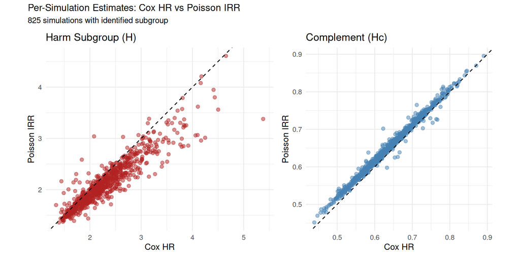

Cox HR vs Poisson IRR within identified subgroups. Points near the diagonal confirm the Poisson-Cox equivalence for estimation.

```r
cox_sg <- cox_h1[cox_h1$any.H == 1, c("sim", "hr.H.hat", "hr.Hc.hat")]
irr_sg <- irr_h1[irr_h1$any.H == 1, c("sim", "hr.H.hat", "hr.Hc.hat")]
sg_df <- merge(cox_sg, irr_sg, by = "sim", suffixes = c("_cox", "_irr"))

p1 <- ggplot(sg_df, aes(x = hr.H.hat_cox, y = hr.H.hat_irr)) +
  geom_point(alpha = 0.5, size = 2, colour = "firebrick") +
  geom_abline(slope = 1, intercept = 0, linetype = "dashed") +
  labs(title = "Harm Subgroup (H)", x = "Cox HR", y = "Poisson IRR") +
  coord_equal() + theme_minimal(base_size = 12)

p2 <- ggplot(sg_df, aes(x = hr.Hc.hat_cox, y = hr.Hc.hat_irr)) +
  geom_point(alpha = 0.5, size = 2, colour = "steelblue") +
  geom_abline(slope = 1, intercept = 0, linetype = "dashed") +
  labs(title = "Complement (Hc)", x = "Cox HR", y = "Poisson IRR") +
  coord_equal() + theme_minimal(base_size = 12)

p1 + p2 + plot_annotation(
  title = "Per-Simulation Estimates: Cox HR vs Poisson IRR",
  subtitle = sprintf("%d simulations with identified subgroup", nrow(sg_df)))
```

# 8 Part IV: Corrected Null Approximation

The per-subgroup approximation $P_1$ models a single pre-specified subgroup. Under $H_0$, the procedure evaluates many candidates, and the effective number of viable candidates grows with $N$.

## 8.1 Multi-N Null Simulations for Calibration

To calibrate $L_{\text{eff}}$ we need H0 simulations at multiple sample sizes ($N \in \{300, 500, 700\}$, defined in the setup chunk).

```r
n_sims_cal <- nsims_null  # use same count as main sims

cat("Running multi-N null calibration simulations...\n")
```

```
#> Running multi-N null calibration simulations...
```

```r
cat(sprintf("N values: %s | Sims per N: %d\n",
            paste(N_cal_values, collapse = ", "), n_sims_cal))
```

```
#> N values: 300, 500, 700 | Sims per N: 10000
```

```r
t0 <- proc.time()[3]

cal_results <- list()
for (N_val in N_cal_values) {
  t_N <- proc.time()[3]

  res_N <- foreach(
    sim = seq_len(n_sims_cal),
    .combine = rbind, .errorhandling = "remove",
    .options.future = list(
      packages = c("forestsearch", "survival", "data.table", "future"),
      seed = TRUE)
  ) %dofuture% {
    future::plan("sequential")
    run_simulation_analysis(
      sim_id = sim, dgm = dgm_null,
      n_sample = N_val,
      analysis_time = sim_config$analysis_time,
      cens_adjust = sim_config$cens_adjust,
      confounders_base = confounders_base,
      cox_formula_adj = survival::Surv(y_sim, event_sim) ~ treat_sim + z1 + z2 + z3,
      n_add_noise = 0L,
      run_fs = TRUE, run_fs_grf = FALSE, run_grf = FALSE,
      fs_params = fs_params_cox, verbose = FALSE
    )
  }

  fs_rows <- res_N[res_N$analysis == "FS", ]
  fpr_N <- mean(fs_rows$any.H, na.rm = TRUE)

  cal_results[[as.character(N_val)]] <- data.frame(
    N = N_val, sim_fpr = fpr_N, n_sims = nrow(fs_rows)
  )

  cat(sprintf("  N = %4d: FPR = %.3f (%d sims) | %.1f sec\n",
      N_val, fpr_N, nrow(fs_rows), proc.time()[3] - t_N))
}
```

```
#>   N =  300: FPR = 0.054 (10000 sims) | 3207.3 sec
#>   N =  500: FPR = 0.066 (10000 sims) | 608.7 sec
#>   N =  700: FPR = 0.056 (10000 sims) | 780.3 sec
```

```r
cal_df <- do.call(rbind, cal_results)
timings$null_cal <- proc.time()[3] - t0
cat(sprintf("Multi-N calibration: %.1f min\n", timings$null_cal / 60))
```

```
#> Multi-N calibration: 76.6 min
```

## 8.2 Compute Per-Subgroup $P_1$ at Each N

```r
cal_df$n_H <- n_min_val
cal_df$d_eff <- round(d_eff_survival(cal_df$n_H, prop_cens))

cal_df$P1 <- sapply(cal_df$d_eff, function(d) {
  p_detect_glm(1.0, d, 1.25, 1.0)
})

cat("=== Per-Subgroup P1 vs Simulated FPR ===\n")
```

```
#> === Per-Subgroup P1 vs Simulated FPR ===
```

```r
cal_df$ratio <- round(cal_df$sim_fpr / pmax(cal_df$P1, 0.001), 2)
print(cal_df[, c("N", "n_H", "d_eff", "P1", "sim_fpr", "ratio")])
```

```
#>       N n_H d_eff       P1 sim_fpr ratio
#> 300 300  60    32 0.194358  0.0538  0.28
#> 500 500  60    32 0.194358  0.0657  0.34
#> 700 700  60    32 0.194358  0.0555  0.29
```

## 8.3 Calibrate $L_{\text{eff}}$

```r
# Implied L_eff
cal_df$L_eff <- log(1 - cal_df$sim_fpr) / log(1 - cal_df$P1)

cat("=== Implied L_eff ===\n")
```

```
#> === Implied L_eff ===
```

```r
print(cal_df[, c("N", "n_H", "d_eff", "P1", "sim_fpr", "L_eff")])
```

```
#>       N n_H d_eff       P1 sim_fpr     L_eff
#> 300 300  60    32 0.194358  0.0538 0.2558874
#> 500 500  60    32 0.194358  0.0657 0.3144504
#> 700 700  60    32 0.194358  0.0555 0.2642083
```

```
#> L_eff Calibration
#>   Model: L_eff = 0.241 * (N / 60)^0.068
#>   R-squared: 0.068
#>   Calibrated at N = 300, 500, 700
#>
#>   Implied L_eff:
#>     N =  300: L_eff = 0.26 (fitted: 0.27)
#>     N =  500: L_eff = 0.31 (fitted: 0.28)
#>     N =  700: L_eff = 0.26 (fitted: 0.28)
```

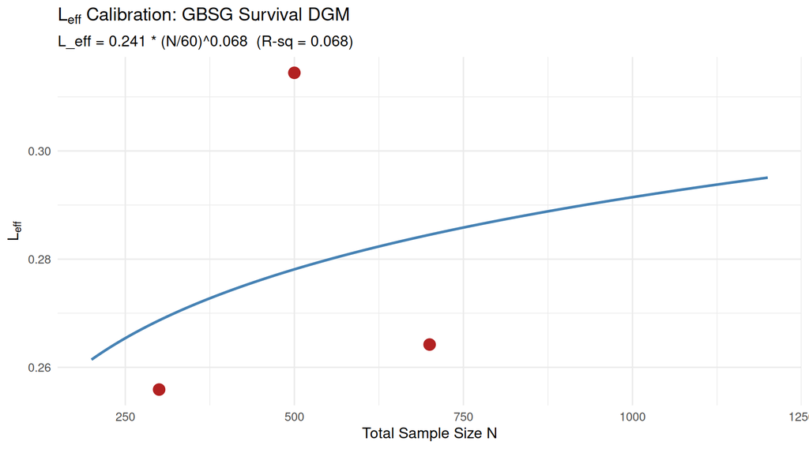

Implied L_eff at each N with power-law fit for the GBSG survival DGM.

```
#>
#> Fitted model: L_eff = 0.241 * (N/60)^0.068
#>   N =  300: L_eff = 0.27
#>   N =  500: L_eff = 0.28
#>   N =  700: L_eff = 0.28
```

```r
# Filter to valid rows (sim_fpr > 0 and P1 > 0)
cal_valid <- cal_df[cal_df$sim_fpr > 0 & cal_df$P1 > 0 &
                     is.finite(cal_df$L_eff), ]

if (nrow(cal_valid) >= 2) {
  leff_cal <- calibrate_L_eff(
    N       = cal_valid$N,
    P1      = cal_valid$P1,
    sim_fpr = cal_valid$sim_fpr,
    n_min   = n_min_val
  )
  print(leff_cal)

  C_fit <- leff_cal$C
  alpha_fit <- leff_cal$alpha

  N_pred <- seq(200, 1200, by = 5)
  pred_curve <- data.frame(
    N = N_pred,
    L_eff = C_fit * (N_pred / n_min_val)^alpha_fit
  )

  print(
    ggplot() +
      geom_point(data = cal_valid,
                 aes(x = N, y = L_eff), size = 4, colour = "firebrick") +
      geom_line(data = pred_curve,
                aes(x = N, y = L_eff), colour = "steelblue",
                linewidth = 1) +
      labs(x = "Total Sample Size N",
           y = expression(L[eff]),
           title = expression(L[eff] * " Calibration: GBSG Survival DGM"),
           subtitle = sprintf("L_eff = %.3f * (N/%d)^%.3f  (R-sq = %.3f)",
                               C_fit, n_min_val, alpha_fit,
                               leff_cal$r_squared)) +
      theme_minimal(base_size = 12) +
      theme(plot.title = element_text(face = "bold"))
  )

  cat(sprintf("\nFitted model: L_eff = %.3f * (N/%d)^%.3f\n",
              C_fit, n_min_val, alpha_fit))
  for (N_val in N_cal_values) {
    cat(sprintf("  N = %4d: L_eff = %.2f\n", N_val,
                C_fit * (N_val / n_min_val)^alpha_fit))
  }
} else {
  cat("Insufficient valid calibration points (need >= 2).\n")
  cat("Using fallback L_eff = 1 (no correction).\n")
  C_fit <- 1 / (n_sample / n_min_val)
  alpha_fit <- 1
}
```

## 8.4 Save $L_{\text{eff}}$ Calibration

```r
# Save calibration to .rds for downstream documents (S2)
save_leff_calibration(
  C = C_fit,
  alpha = alpha_fit,
  n_min = n_min_val,
  outcome_type = "survival",
  cal_data = cal_df,
  dgm_description = paste(
    "GBSG survival DGM,", length(confounders_base), "confounders",
    paste0("(", paste(confounders_base, collapse = ", "), "),"),
    sprintf("prop_cens=%.2f, p_harm=%.2f", prop_cens, p_harm)),
  n_sims_per_N = n_sims_cal,
  output_dir = output_dir,
  extra = list(
    # ForestSearch config (S2 should match these)
    confounders_base = confounders_base,
    prop_cens        = prop_cens,
    p_harm           = p_harm,
    hr_h1            = hr_h1,
    pcons            = pcons,
    fs_splits        = fs_splits,
    maxk_val         = maxk_val,
    n_min_val        = n_min_val,
    analysis_time    = analysis_time,
    cens_adjust      = cens_adjust,
    fpr_target       = fpr_target,
    N_cal_values     = N_cal_values,
    # Grid range validated for L_eff threshold-independence
    # (not swept in C2; C3 provides this via its grid sweep)
    c1_range = c(1.00, 1.50),
    c2_range = c(0.90, 1.25)
  )
)
```

```
#> L_eff calibration saved: _data/calibration_survival_leff.rds
```

```
#>   outcome: survival | C = 0.2410 | alpha = 0.0676 | n_min = 60
```

```
#>   Size: 0.8 KB
```

**ImportantShared `.rds` With C3**

## 8.5 Corrected Four-Way Table

```r
L_eff_main <- C_fit * (n_sample / n_min_val)^alpha_fit

P1_cox <- compute_detection_probability(
  1.0, n_H_dgm, prop_cens, 1.25, 1.0)
P1_glm <- p_detect_glm(1.0, d_dgm, 1.25, 1.0)

fpr_corr_cox <- 1 - (1 - P1_cox)^L_eff_main
fpr_corr_glm <- 1 - (1 - P1_glm)^L_eff_main

four_way_corr <- data.frame(
  Calculation = c(
    "(D) Cox Approx (uncorrected)",
    "(D') Cox Approx (L_eff corrected)",
    "(C) Cox Simulation",
    "(B) GLM Approx (uncorrected)",
    "(B') GLM Approx (L_eff corrected)",
    "(A) GLM (Poisson) Simulation"
  ),
  `P(theta=1.0)` = c(
    round(P1_cox, 3),
    round(fpr_corr_cox, 3),
    round(mean(cox_h0$any.H), 3),
    round(P1_glm, 3),
    round(fpr_corr_glm, 3),
    round(mean(irr_h0$any.H), 3)
  ),
  `P(theta=hr_h1)` = c(
    round(compute_detection_probability(hr_h1, n_H_dgm, prop_cens, 1.25, 1.0), 3),
    NA,
    round(mean(cox_h1$any.H), 3),
    round(p_detect_glm(hr_h1, d_dgm, 1.25, 1.0), 3),
    NA,
    round(mean(irr_h1$any.H), 3)
  ),
  check.names = FALSE
)
names(four_way_corr)[3] <- sprintf("P(theta=%.1f)", hr_h1)

gt(four_way_corr) |>
  tab_header(
    title = md("**Four-Way Comparison with L_eff Correction**"),
    subtitle = sprintf("N=%d, n(H)=%d, d=%d, L_eff=%.2f",
                        n_sample, n_H_dgm, d_dgm, L_eff_main)
  ) |>
  sub_missing(missing_text = "\u2014") |>
  tab_row_group(label = "GLM (Poisson+offset)",
    rows = grepl("GLM|\\(A\\)|\\(B\\)", Calculation)) |>
  tab_row_group(label = "Cox PH",
    rows = grepl("Cox|\\(C\\)|\\(D\\)", Calculation)) |>
  tab_source_note(md(paste0(
    "**Corrected rows (D', B')** should match simulation rows (C, A). ",
    sprintf("Power (theta=%.1f) does not need correction.", hr_h1))))
```

Four-way comparison with L_eff-corrected null approximation. The corrected row should align with simulation.

**Four-Way Comparison with L_eff Correction**

N=700, n(H)=60, d=32, L_eff=0.28

| Calculation | P(theta=1.0) | P(theta=2.0) |
| --- | --- | --- |
| Cox PH |  |  |
| (D) Cox Approx (uncorrected) | 0.194 | 0.825 |
| (D') Cox Approx (L_eff corrected) | 0.059 | — |
| (C) Cox Simulation | 0.056 | 0.825 |
| GLM (Poisson+offset) |  |  |
| (B) GLM Approx (uncorrected) | 0.194 | 0.822 |
| (B') GLM Approx (L_eff corrected) | 0.060 | — |
| (A) GLM (Poisson) Simulation | 0.095 | 0.879 |

**Corrected rows (D’, B’)** should match simulation rows (C, A). Power (theta=2.0) does not need correction.

## 8.6 Correction Assessment

```r
cat(sprintf("=== L_eff Correction Assessment (N = %d) ===\n\n", n_sample))
```

```
#> === L_eff Correction Assessment (N = 700) ===
```

```r
cat(sprintf("L_eff at N=%d: %.2f\n", n_sample, L_eff_main))
```

```
#> L_eff at N=700: 0.28
```

```r
cat(sprintf("  (i.e., %.1f effectively independent candidates)\n\n",
            L_eff_main))
```

```
#>   (i.e., 0.3 effectively independent candidates)
```

```r
cat("Cox PH (H0):\n")
```

```
#> Cox PH (H0):
```

```r
cat(sprintf("  Uncorrected P1:    %.3f\n", P1_cox))
```

```
#>   Uncorrected P1:    0.194
```

```r
cat(sprintf("  Corrected:         %.3f\n", fpr_corr_cox))
```

```
#>   Corrected:         0.059
```

```r
cat(sprintf("  Simulated:         %.3f\n", mean(cox_h0$any.H)))
```

```
#>   Simulated:         0.056
```

```r
cat(sprintf("  Sim/Uncorrected:   %.2f\n",
            mean(cox_h0$any.H) / max(P1_cox, 0.001)))
```

```
#>   Sim/Uncorrected:   0.29
```

```r
cat(sprintf("  Sim/Corrected:     %.2f\n\n",
            mean(cox_h0$any.H) / max(fpr_corr_cox, 0.001)))
```

```
#>   Sim/Corrected:     0.93
```

```r
cat("GLM Poisson (H0):\n")
```

```
#> GLM Poisson (H0):
```

```r
cat(sprintf("  Uncorrected P1:    %.3f\n", P1_glm))
```

```
#>   Uncorrected P1:    0.194
```

```r
cat(sprintf("  Corrected:         %.3f\n", fpr_corr_glm))
```

```
#>   Corrected:         0.060
```

```r
cat(sprintf("  Simulated:         %.3f\n", mean(irr_h0$any.H)))
```

```
#>   Simulated:         0.095
```

```r
cat(sprintf("  Sim/Uncorrected:   %.2f\n",
            mean(irr_h0$any.H) / max(P1_glm, 0.001)))
```

```
#>   Sim/Uncorrected:   0.49
```

```r
cat(sprintf("  Sim/Corrected:     %.2f\n",
            mean(irr_h0$any.H) / max(fpr_corr_glm, 0.001)))
```

```
#>   Sim/Corrected:     1.59
```

## 8.7 Comparison to Binary Calibration

```r
cat("=== Cross-DGM L_eff Comparison ===\n\n")
```

```
#> === Cross-DGM L_eff Comparison ===
```

```r
cat("The L_eff calibration depends on the candidate generation\n")
```

```
#> The L_eff calibration depends on the candidate generation
```

```r
cat("process, not the outcome type.\n\n")
```

```
#> process, not the outcome type.
```

```r
cat(sprintf("GBSG Survival DGM (%d confounders): C=%.3f, alpha=%.3f\n",
            length(confounders_base), C_fit, alpha_fit))
```

```
#> GBSG Survival DGM (7 confounders): C=0.241, alpha=0.068
```

```r
cat(sprintf("  L_eff(N=%d) = %.2f\n\n", n_sample, L_eff_main))
```

```
#>   L_eff(N=700) = 0.28
```

```r
cat("Binary DGM (4 confounders): see calibration_binary_leff.qmd\n")
```

```
#> Binary DGM (4 confounders): see calibration_binary_leff.qmd
```

```r
cat("  Expected: smaller L_eff (fewer confounders -> fewer candidates)\n")
```

```
#>   Expected: smaller L_eff (fewer confounders -> fewer candidates)
```

# 9 Summary

## 9.2 Implications for Other GLM Outcomes

The Poisson+offset case is a validation anchor: since it targets the same quantity as the Cox model, agreement confirms the GLM infrastructure. For other outcome types:

| Outcome | $d_{\text{eff}}$ | Validation status |
| --- | --- | --- |
| Poisson + offset | $D$ (events) = $d$ (Cox) | Validated here |
| Binary (logit) | $n_H \bar p(1-\bar p)$ | Requires separate calibration |
| Continuous | $n_H / \sigma^2$ | Requires separate calibration |

The binary case has $d_{\text{eff}} < d$ (Cox) for typical event rates, explaining why the survival defaults (c1=1.25, c2=1.0) do not provide adequate FPR control for binary outcomes.

## 9.3 References

- Leon, L.F., Jemielita, T., Guo, Z., Marceau West, R., Anderson, K.M. (2024). Exploratory subgroup identification in the heterogeneous Cox model. *Statistics in Medicine*, 43, 4253–4275.
- Jennison, C. and Turnbull, B.W. (1984). Repeated confidence intervals for group sequential clinical trials. *Controlled Clinical Trials*, 5(1), 33–45.
- McCullagh, P. and Nelder, J.A. (1989). *Generalized Linear Models*, 2nd ed. Chapman and Hall.
- Laird, N. and Olivier, D. (1981). Covariance analysis of censored survival data using log-linear analysis techniques. *Journal of the American Statistical Association*, 76(374), 231–240.
- Whitehead, J. (1980). Fitting Cox’s regression model to survival data using GLIM. *Journal of the Royal Statistical Society C*, 29(3), 268–275.

# 10 Save All Simulation Results

The simulation results are computationally expensive (hours). Save everything to `.rds` so downstream documents and future analyses can reload without re-running.

```r
if (!dir.exists(output_dir)) dir.create(output_dir, recursive = TRUE)

sim_bundle <- list(

  # Metadata
  params = list(
    nsims_alt = nsims_alt,
    nsims_null = nsims_null,
    sim_seed = sim_seed,
    n_workers = n_workers,
    n_sample = n_sample,
    hr_h1 = hr_h1,
    analysis_time = analysis_time,
    cens_adjust = cens_adjust,
    fpr_target = fpr_target,
    prop_cens = prop_cens,
    p_harm = p_harm,
    n_min_val = n_min_val,
    N_cal_values = N_cal_values,
    sim_config = sim_config,
    fs_params_base = fs_params_base,
    fs_params_cox = fs_params_cox,
    fs_params_irr = fs_params_irr,
    confounders_base = confounders_base,
    timestamp = Sys.time(),
    R_version = R.version.string,
    forestsearch_version = tryCatch(
      as.character(utils::packageVersion("forestsearch")),
      error = function(e) "unknown")
  ),

  # DGM objects
  dgm_alt = dgm_alt,
  dgm_null = dgm_null,

  # Raw simulation results (the expensive part)
  results_alt_cox = results_alt_cox,
  results_null_cox = results_null_cox,
  results_alt_irr = results_alt_irr,
  results_null_irr = results_null_irr,

  # L_eff calibration
  leff = list(
    C = C_fit,
    alpha = alpha_fit,
    n_min = n_min_val,
    cal_df = cal_df
  ),

  # Timing
  timings = timings
)

rds_path <- file.path(output_dir,
  sprintf("calibration_survival_fourway_%s.rds",
          format(Sys.Date(), "%Y%m%d")))
saveRDS(sim_bundle, rds_path)

cat(sprintf("=== All results saved ===\n"))
```

```
#> === All results saved ===
```

```r
cat(sprintf("  File: %s\n", rds_path))
```

```
#>   File: _data/calibration_survival_fourway_20260403.rds
```

```r
cat(sprintf("  Size: %.1f MB\n", file.size(rds_path) / 1024^2))
```

```
#>   Size: 1.9 MB
```

```r
cat(sprintf("  Contents:\n"))
```

```
#>   Contents:
```

```r
cat(sprintf("    results_alt_cox:  %d rows\n", nrow(results_alt_cox)))
```

```
#>     results_alt_cox:  1000 rows
```

```r
cat(sprintf("    results_null_cox: %d rows\n", nrow(results_null_cox)))
```

```
#>     results_null_cox: 10000 rows
```

```r
cat(sprintf("    results_alt_irr:  %d rows\n", nrow(results_alt_irr)))
```

```
#>     results_alt_irr:  1000 rows
```

```r
cat(sprintf("    results_null_irr: %d rows\n", nrow(results_null_irr)))
```

```
#>     results_null_irr: 10000 rows
```

```r
cat(sprintf("    cal_df:           %d rows (N = %s)\n",
            nrow(cal_df), paste(cal_df$N, collapse = ", ")))
```

```
#>     cal_df:           3 rows (N = 300, 500, 700)
```

```r
cat(sprintf("    L_eff:            C=%.4f, alpha=%.4f\n",
            C_fit, alpha_fit))
```

```
#>     L_eff:            C=0.2410, alpha=0.0676
```

## 10.1 How to Reload

```r
# Load the most recent simulation bundle
res <- readRDS(latest_rds("calibration_survival_fourway"))

# Access simulation results directly
cox_h1 <- res$results_alt_cox[res$results_alt_cox$analysis == "FS", ]
cox_h0 <- res$results_null_cox[res$results_null_cox$analysis == "FS", ]
irr_h1 <- res$results_alt_irr[res$results_alt_irr$analysis == "FS", ]
irr_h0 <- res$results_null_irr[res$results_null_irr$analysis == "FS", ]

# Check what was run
res$params$nsims_alt        # number of H1 sims
res$params$nsims_null       # number of H0 sims
res$params$hr_h1            # HR for harm subgroup
res$params$analysis_time    # GBSG analysis time
res$params$fpr_target       # FPR target

# L_eff calibration
res$leff$C               # fitted C
res$leff$alpha           # fitted alpha
res$leff$cal_df          # raw calibration data

# Re-derive metrics without re-running
cat("Cox H0 FPR:", mean(cox_h0$any.H), "\n")
cat("Cox H1 Power:", mean(cox_h1$any.H), "\n")
cat("IRR H0 FPR:", mean(irr_h0$any.H), "\n")
cat("IRR H1 Power:", mean(irr_h1$any.H), "\n")
```

# 11 Timing and Session Info

```r
timings$total <- (proc.time() - t_vignette_start)["elapsed"]

timing_df <- data.frame(
  Stage = c("DGM", "Cox H1", "Cox H0",
            "IRR H1", "IRR H0",
            "L_eff Calibration (multi-N)",
            "Total"),
  Seconds = c(timings$dgm, timings$alt_cox, timings$null_cox,
              timings$alt_irr, timings$null_irr,
              timings$null_cal, timings$total),
  stringsAsFactors = FALSE
)
timing_df$Minutes <- timing_df$Seconds / 60

gt(timing_df) |>
  tab_header(
    title = "Computational Timing Summary",
    subtitle = sprintf(
      "%d H1 sims + %d H0 sims + %d cal sims x %d N | %d workers",
      nsims_alt, nsims_null, n_sims_cal,
      length(N_cal_values), n_workers)
  ) |>
  fmt_number(columns = Seconds, decimals = 1) |>
  fmt_number(columns = Minutes, decimals = 2) |>
  cols_label(Stage = "Stage", Seconds = "Time (sec)",
             Minutes = "Time (min)") |>
  tab_style(
    style = cell_text(weight = "bold"),
    locations = cells_body(rows = Stage == "Total")
  )
```

Computational Timing Summary

1000 H1 sims + 10000 H0 sims + 10000 cal sims x 3 N | 121 workers

| Stage | Time (sec) | Time (min) |
| --- | --- | --- |
| DGM | 3.8 | 0.06 |
| Cox H1 | 104.6 | 1.74 |
| Cox H0 | 786.2 | 13.10 |
| IRR H1 | 98.5 | 1.64 |
| IRR H0 | 877.3 | 14.62 |
| L_eff Calibration (multi-N) | 4,596.2 | 76.60 |
| Total | 6,503.9 | 108.40 |

```r
plan(sequential)
```